# Land Use Disadvantages in Germany: A Matter of Ethnic Income Inequalities - Supplementary Analysis and Material (Results)

Anonymous

2021-03-23

# TABLE A: Full Regression Table

Table 2 in the paper only shows regression coefficients for the migration background variable and income. Here we can see the full regression table including the control variables for age, gender, education, household size, german region and survey year interaction, inhabitant size of the municipality, and distance to municipality administration.

[output not shown]

# FIGURE A: Income Distribution

We may ask whether income is distributed differently across Germans and migrants. The following figure shows that this is not the case, although the group of Germans comprises slightly more respondents in higher-income ranges.

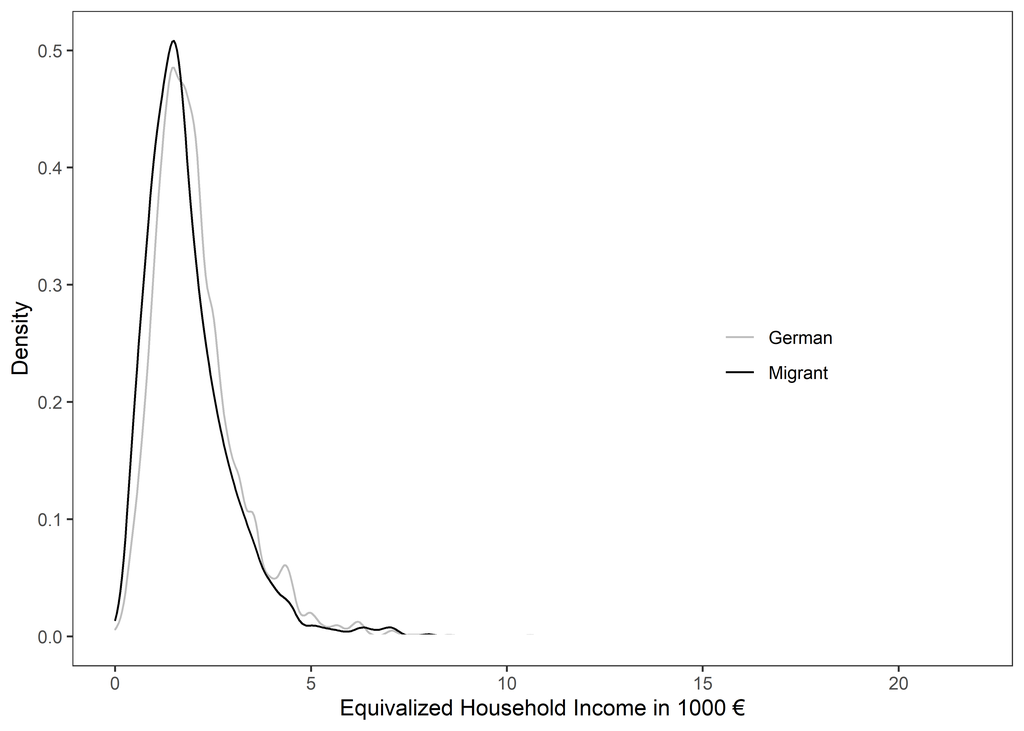

# FIGURE B: Average Marginal Effect Plot

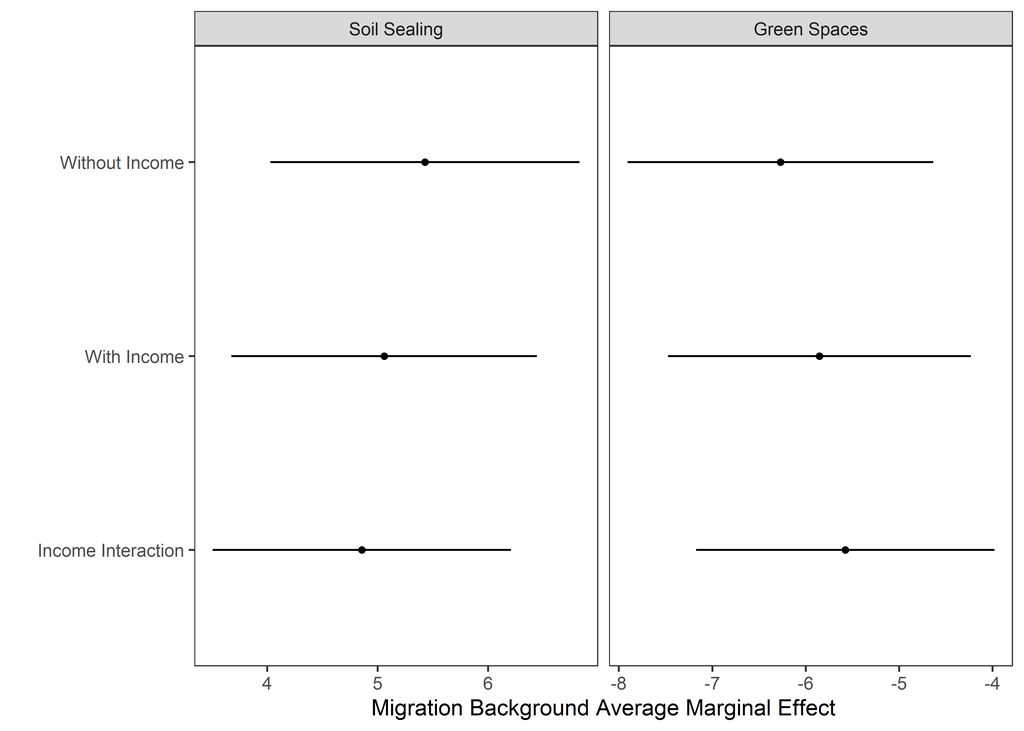

# Urban Interaction Plots

## FIGURE C: Predictions

The paper only includes tables using the second difference test to test whether non-urban and urban areas differ in the interactive relationship between income, migration background, and environmental disadvantages. We can also observe differences between those areas by looking at the actual predictions like in Figure 2 of the paper.

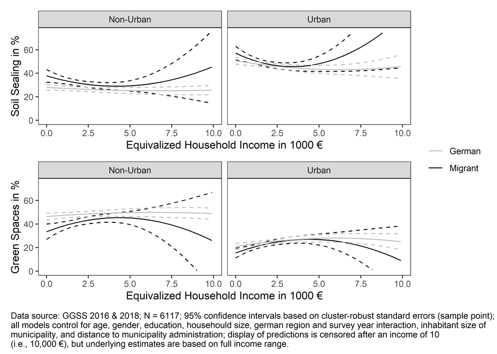

## FIGURE D: Average Marginal Effect

The average marginal effect of migration background across the income variable for non-urban and urban areas demonstrates statistically significant differences between Germans and migrants. Interestingly, the most striking differences are in non-urban areas, which corroborates Table 4 in the paper.

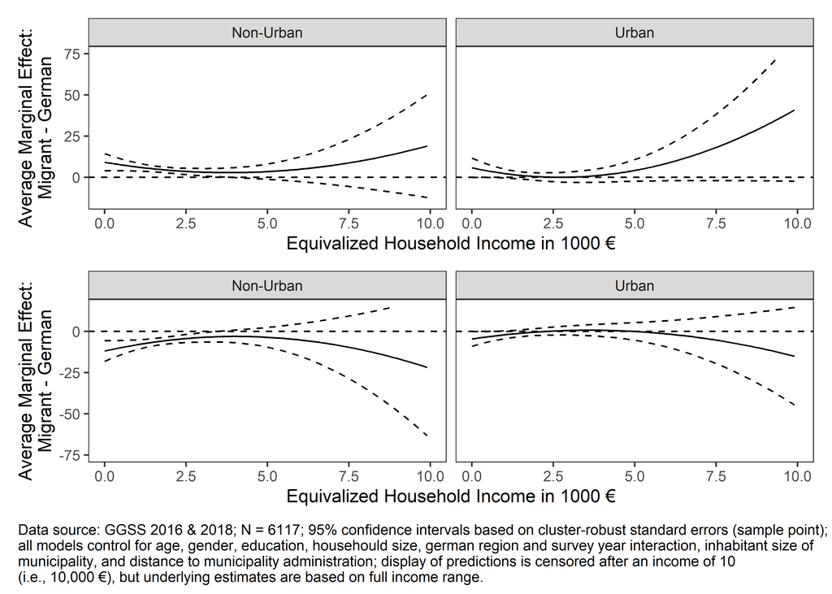

# Alternative Buffer Sizes

Researchers’ degrees of freedom is enormous, especially when it comes to geospatial data. To demonstrate that 500 meters buffer zones were not chosen because of ‘better’ p-values in the analysis, the following shows predictions for soil sealing and green spaces in 100, 250, 750, and 1000 meters buffer zones.

## FIGURE E: Soil Sealing

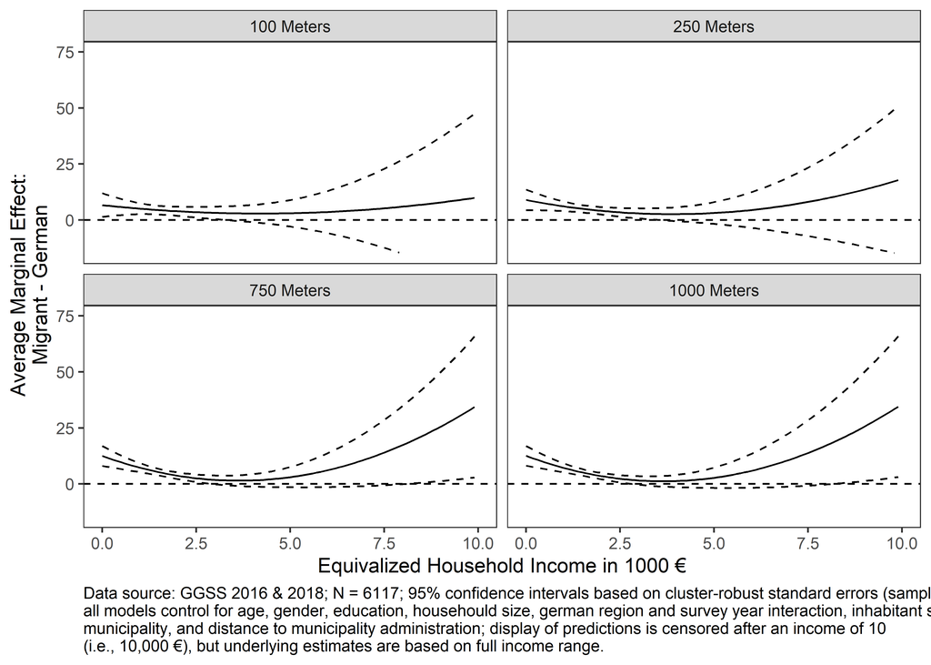

## FIGURE F: Green Spaces

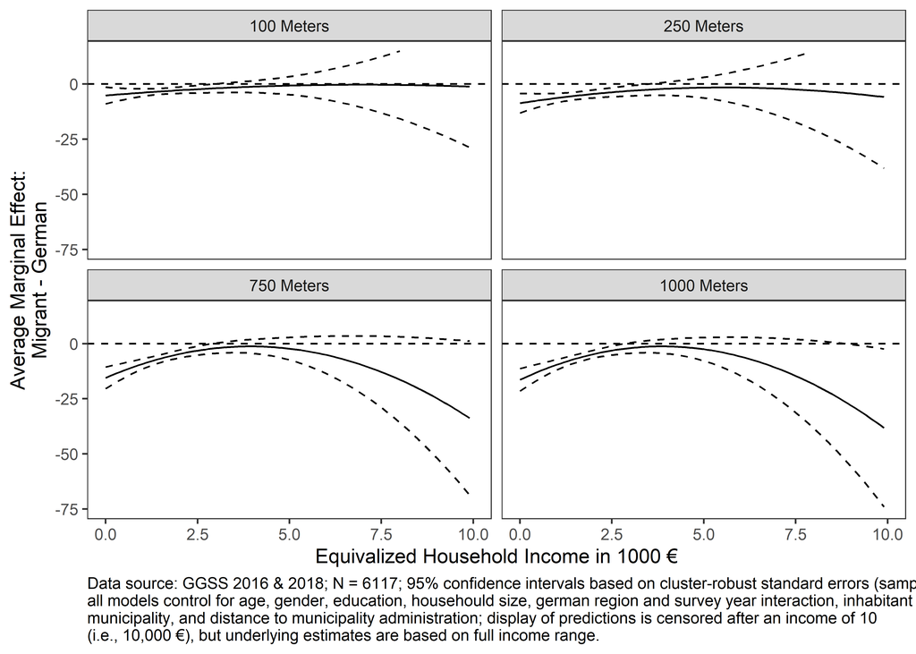

# Alternative Land Use Indicators

Soil sealing and the used green spaces indicator in the paper are rather broad indicators, which were necessary to use as we rely on a broad population sample comprising respondents from non-urban and urban areas. In order to demonstrate their significance, some analyses with additional indicators were also made.

## FIGURE G: Blue Spaces (Water)

Blue spaces (i.e., water areas such as lakes, ponds, and rivers) are also discussed in the environmental justice literature, similar to green spaces. The IOER Monitor also includes an indicator for such areas, which depicts the percentage of water in a specific area. However, only a few respondents can score high on this indicator, so that the results may indicate an unequal distribution of environmental disadvantage, but it is not very striking.

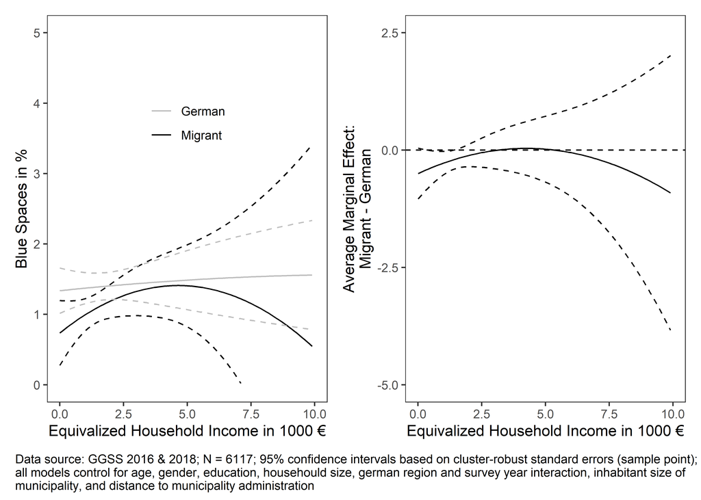

## FIGURE H: Streets Minus Ecotone

Another possibly more innovative indicator is computed by relating street network density to ecotone density. As written in footnote 1 of the paper, an ecotone is a boundary of rapid change between two biological communities (Attrill and Rundle, 2002) embodying trees or hedges. By subtracting its density from street density, we can obtain an indicator for areas covered by many streets and lacking trees. All areas with an ecotone surplus (negative values) were coded as `0`. Living in areas with high values should then depict a suitable indicator for an environmental disadvantage stemming from streets. In fact, the results corroborate the findings from the paper.

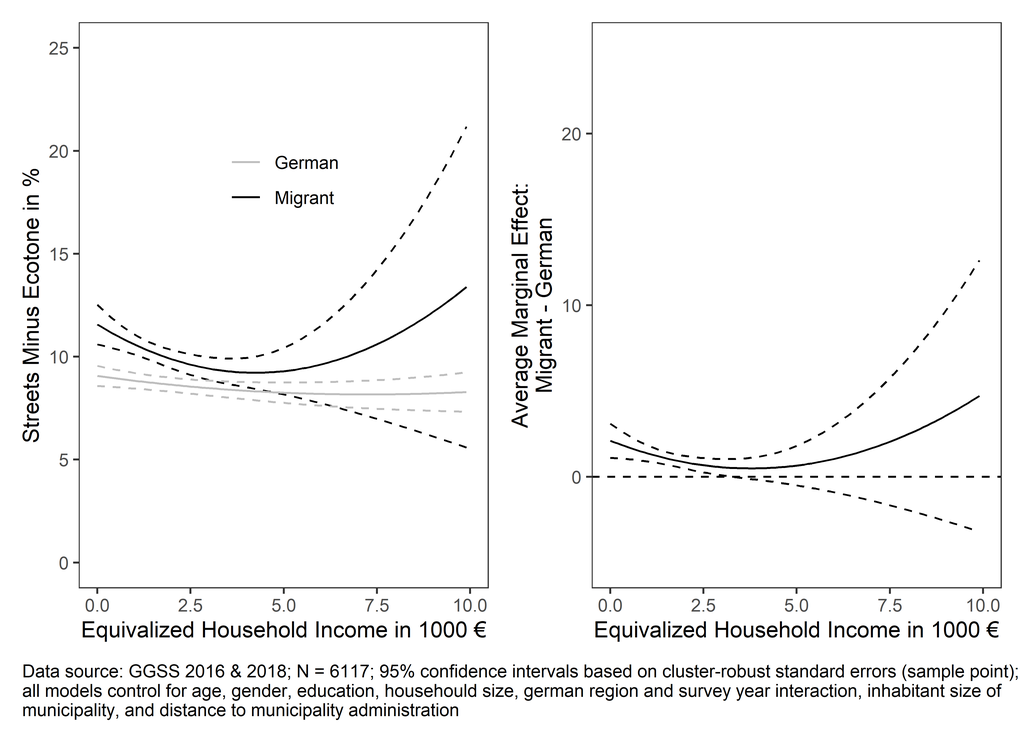

## FIGURE I: Urban Green

A more classic indicator is urban green areas such as parks. The IOER Monitor also includes such an indicator for municipalities with more than 50,000 inhabitants. However, exploiting the indicator reduces the overall sample to 2,227 survey respondents. Besides, the results only show minor differences between Germans and migrants, which might also corroborate the results from the urban interaction models.

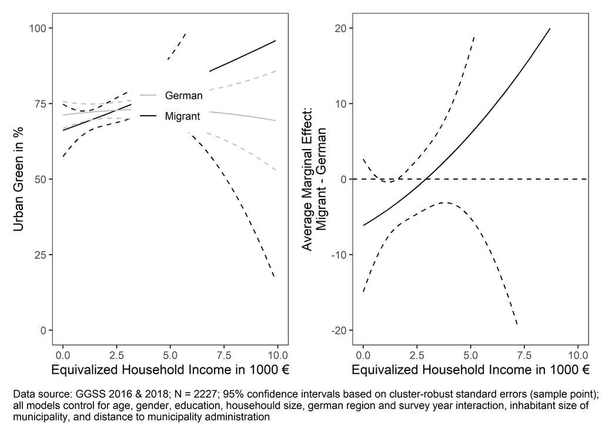